# Experimentos

## Introdução

No Cap. 2, mostramos que a ignorabilidade forte — independência entre resultados potenciais e tratamento, condicional a $\mathbf{X}_i$ — identifica o ATE. No Cap. 3, vimos que o critério backdoor nos diz *quais* covariáveis incluir para garantir essa independência. Agora veremos o caso ideal: quando a pesquisadora *controla* o mecanismo de atribuição do tratamento — o **experimento aleatório** — e a ignorabilidade é garantida por construção.

Um experimento é o desenho de pesquisa no qual a pesquisadora controla o mecanismo de atribuição do tratamento. Seja $p_i = P(D_i = 1)$ a probabilidade de a unidade $i$ receber o tratamento. Em um experimento, $p_i$ é conhecido e controlado pela pesquisadora. Em contraposição, um estudo observacional é quando a pesquisadora não controla esse mecanismo — ele é determinado pela natureza ou pela realidade social.

Neste capítulo, veremos por que experimentos produzem identificação causal crível. Vamos supor condições ideais: sem *attrition* (perda de participantes) e com *compliance* perfeito (todos recebem o tratamento atribuído). Continuamos supondo SUTVA (Cap. 2): não há interferência entre unidades e o tratamento é definido de forma não ambígua.

## Recapitulação: SDO e viés de seleção

No Cap. 2, derivamos que a simples diferença de médias (SDO, *Simple Difference in Outcomes*) pode ser decomposta em efeito causal mais viés:

$$\underbrace{\mathbb{E}[Y_i \mid D_i=1] -
\mathbb{E}[Y_i \mid D_i=0]}_{\text{SDO}} = \underbrace{\mathbb{E}[Y_i(1)
- Y_i(0) \mid D_i=1]}_{\text{ATT}} + \underbrace{\mathbb{E}[Y_i(0) \mid
D_i=1] - \mathbb{E}[Y_i(0) \mid D_i=0]}_{\text{Viés de
Seleção}}$$

O viés de seleção surge quando tratados e controles diferem sistematicamente nos resultados potenciais de base. A questão central deste capítulo é: **como a aleatorização elimina esse viés?**

## Experimentos aleatórios e identificação

Um experimento aleatório satisfaz duas condições:

1. **Positividade**: toda unidade tem probabilidade positiva de receber tratamento ou controle: $0 < p_i < 1$.
2. **Permutabilidade** (*unconfoundedness*): os resultados potenciais são independentes do tratamento: $Y_i(1), Y_i(0) \perp D_i$.

Em termos do Cap. 3, a aleatorização garante que não haja backdoor paths abertos entre o tratamento e o resultado — pois o tratamento não tem causas que também afetem $Y$.

O que a permutabilidade implica? Se os resultados potenciais são independentes do tratamento, então:

$$\mathbb{E}[Y_i(0) \mid D_i=1] =
\mathbb{E}[Y_i(0) \mid D_i=0] = \mathbb{E}[Y_i(0)]$$

Ou seja, o viés de seleção desaparece:

$$\mathbb{E}[Y_i(0) \mid D_i=1] -
\mathbb{E}[Y_i(0) \mid D_i=0] = 0$$

Portanto, sob aleatorização, a SDO estima o ATT. E como a permutabilidade também implica $\mathbb{E}[Y_i(1) \mid D_i=1] = \mathbb{E}[Y_i(1)]$, o ATT é igual ao ATE:

$$\text{SDO} = \text{ATT} =
\tau_{\text{ATE}}$$

*Pare e pense:* se a condição de tratamento fosse hipoteticamente trocada — todos os tratados passassem para o controle e vice-versa — os resultados esperados permaneceriam os mesmos? Essa é a intuição da permutabilidade.

## Restrição de Exclusão

A aleatorização por si só não basta. Precisamos também que o que afeta $Y$ seja o tratamento **efetivamente recebido**, e não o mero fato de ter sido *alocado* para o tratamento. Formalmente, podemos separar a alocação do tratamento $Z_i$ do tratamento efetivamente recebido $D_i$.

A **restrição de exclusão** diz que os resultados potenciais dependem apenas de $D_i$, não de $Z_i$:

$$Y_i(D_i, Z_i = 1) = Y_i(D_i, Z_i = 0) =
Y_i(D_i)$$

Quando essa condição pode ser violada? Quando o mecanismo de alocação dispara outras causas que afetam $Y$. Dois exemplos:

1. **Contaminação.** Suponha que um experimento testa o efeito de transferência de renda sobre bem-estar. Se ONGs, sabendo do experimento, ajudarem quem não recebeu o tratamento, a alocação $Z_i$ afeta $Y_i$ por um canal diferente do tratamento.
2. **Erro de mensuração assimétrico.** Se pesquisadores distintos entrevistam tratados e controles, ou se questionários diferentes são usados para cada grupo, o erro de mensuração pode diferir sistematicamente. Seja $e_{i,1}$ o erro de mensuração para tratados e $e_{i,0}$ para controles. A switching equation se torna:

$$Y_i^{obs} = D_i \cdot (Y_i(1) + e_{i,1})
+ (1 - D_i) \cdot (Y_i(0) + e_{i,0})$$

Nesse caso, a SDO inclui um termo adicional $\mathbb{E}[e_{i,1} \mid D_i=1] - \mathbb{E}[e_{i,0} \mid D_i=0]$, que introduz viés mesmo com aleatorização perfeita.

**Como garantir a restrição de exclusão?**

- **Duplo cego** (*double blindness*): nem o participante nem o pesquisador sabem quem recebeu o tratamento.
- **Paralelismo na administração**: mesmo questionário, mesmos entrevistadores, mesmo protocolo para ambos os grupos.
- Na pior das hipóteses, **aleatorização dos entrevistadores** entre os grupos.

## Tipos de aleatorização

### Aleatorização de Bernoulli

É a aleatorização mais simples: para cada unidade, jogamos uma moeda com probabilidade $p$ de tratamento. Matematicamente, $P(D_i = 1) = p$ independentemente para cada $i$.

O problema é que o número de tratados é aleatório — em princípio, podemos ter todas as unidades no controle ou todas no tratamento (embora isso seja extremamente improvável com $n$ grande).

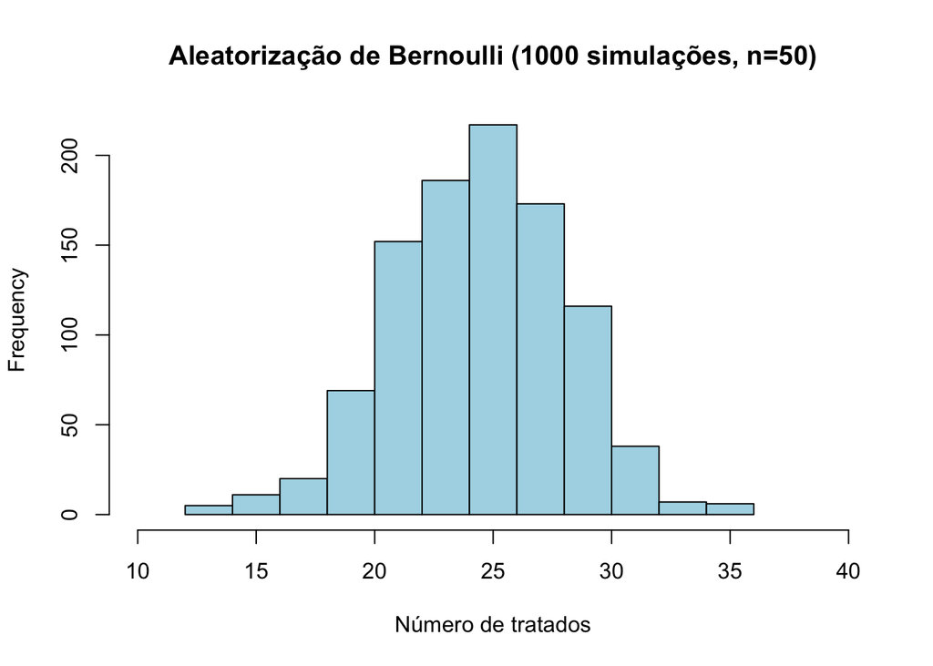

```r
set.seed(10)
n <- 50
hist(replicate(1000, sum(rbinom(n, 1, 0.5))),
     main = "Aleatorização de Bernoulli (1000 simulações, n=50)",
     xlab = "Número de tratados",
     col = "lightblue",
     xlim = c(10, 40))
```

A aleatorização de Bernoulli possui $2^n$ configurações possíveis de alocação entre tratamento e controle.

### Aleatorização completa

Para evitar o problema do número variável de tratados, podemos fixar *a priori* quantas unidades receberão o tratamento. Numeramos cada unidade de $1$ a $N$ e sorteamos $m$ aleatoriamente para o tratamento; o restante vai para o controle.

Vantagem: garante o número de observações em cada grupo. Possui $\binom{N}{m}$ configurações possíveis — estamos descartando as aleatorizações “indesejáveis” (como todos no controle). O cálculo da variância é mais complexo que na aleatorização de Bernoulli.

### Aleatorização condicional (em bloco)

Em muitos contextos, as unidades diferem em características pré-tratamento $X$ que podem afetar o resultado. A **aleatorização em bloco** (*block random assignment*) estratifica as unidades por $X$ e aleatoriza separadamente dentro de cada estrato.

**Exemplo:** Em uma amostra de 100 pessoas, queremos 25 homens e 25 mulheres no tratamento. Sorteamos 25 homens para o tratamento (o restante vai para o controle) e, separadamente, 25 mulheres.

Formalmente, a aleatorização em bloco gera **permutabilidade condicional**: $Y_i(1), Y_i(0) \perp D_i \mid X_i$. Isso é mais fraco que permutabilidade incondicional — o tratamento não é independente dos resultados potenciais marginalmente, mas é independente *dentro de cada estrato*.

Para estimar o ATE na população, calculamos o efeito dentro de cada bloco e ponderamos:

$$\hat{\tau}_{\text{ATE}} = \sum_{j=1}^{J}
\frac{N_j}{N} \hat{\tau}_j$$

onde $J$ é o número de blocos, $N_j$ o tamanho do bloco $j$, e $\hat{\tau}_j$ o efeito estimado no bloco.

**Vantagens da aleatorização em bloco:**

- Pela Lei dos Grandes Números, tende a gerar **balanceamento** entre os grupos — em variáveis observadas *e* não-observadas dentro de cada bloco.
- Em geral, **aumenta a precisão** (reduz o erro padrão), porque removemos parte da variância ao condicionar nos estratos.
- A probabilidade de tratamento pode variar por bloco — essa probabilidade é chamada de *propensity score*.

### Precisão da aleatorização em bloco

Vamos verificar o ganho de precisão com uma simulação. Criamos dois blocos com médias diferentes e comparamos o erro padrão da aleatorização simples com o da aleatorização em bloco.

```r
# Configuração: dois blocos com médias diferentes
n1 <- 10  # bloco 1
n2 <- 16  # bloco 2
N <- n1 + n2

set.seed(12)
y0 <- c(rnorm(n1, 2, 1), rnorm(n2, 6, 1))  # PO controle
y1 <- y0 + 1.5                               # PO tratamento (efeito = 1.5)
```

```r
# Aleatorização em bloco: metade de cada bloco para tratamento
t_bloco1 <- sample(1:n1, n1/2)
c_bloco1 <- (1:n1)[!(1:n1 %in% t_bloco1)]
t_bloco2 <- sample((n1+1):(n1+n2), n2/2)
c_bloco2 <- ((n1+1):(n1+n2))[!((n1+1):(n1+n2) %in% t_bloco2)]

# Resultados observados por bloco
y1_obs_bloco1 <- y1[t_bloco1]; y0_obs_bloco1 <- y0[c_bloco1]
y1_obs_bloco2 <- y1[t_bloco2]; y0_obs_bloco2 <- y0[c_bloco2]

# Aleatorização simples (ignora blocos)
y1_obs <- y1[c(t_bloco1, t_bloco2)]
y0_obs <- y0[c(c_bloco1, c_bloco2)]
```

```r
# Erro padrão: aleatorização simples
ep_simples <- t.test(y1_obs, y0_obs)$stderr

# Erro padrão: aleatorização em bloco (ponderado)
ep1 <- t.test(y1_obs_bloco1, y0_obs_bloco1)$stderr
ep2 <- t.test(y1_obs_bloco2, y0_obs_bloco2)$stderr
ep_bloco <- sqrt(ep1^2 * (n1/N)^2 + ep2^2 * (n2/N)^2)

# Comparação
data.frame(
  Método = c("Aleatorização simples", "Aleatorização em bloco"),
  Erro_Padrão = round(c(ep_simples, ep_bloco), 4)
) |> knitr::kable(caption = "Comparação de erros padrão")
```

Comparação de erros padrão

| Método | Erro_Padrão |
| --- | --- |
| Aleatorização simples | 0.9552 |
| Aleatorização em bloco | 0.3723 |

O erro padrão da aleatorização em bloco é substancialmente menor. A intuição: ao estratificar, eliminamos a variação *entre* blocos (que é grande, pois os blocos têm médias diferentes) e ficamos apenas com a variação *dentro* de cada bloco.

### Aleatorização por cluster

Em alguns contextos, não é possível aleatorizar unidades individuais. Por exemplo, se o tratamento é um programa escolar, pode ser necessário aleatorizar *escolas* inteiras — todos os alunos de uma escola recebem o mesmo tratamento.

Nesse caso, a unidade de aleatorização é o **cluster** (escola), não a unidade de análise (aluno). No interior de cada cluster, todo mundo é tratado ou não-tratado: não há variação *within*, apenas *between*. Isso causa grande perda de variabilidade nos dados, reduzindo a precisão (aumento no erro padrão). Ainda assim, às vezes é a única aleatorização viável.

## Planejando experimentos com DeclareDesign

Uma ferramenta útil para planejar e diagnosticar experimentos é o pacote `DeclareDesign` [@blair2023]. O framework é baseado no acrônimo **MIDA**: *Models* (modelo dos resultados potenciais), *Inquiries* (estimando), *Data strategies* (estratégia de dados/aleatorização) e *Answer strategies* (estimador).

Vamos declarar um experimento simples com dois braços (*two-arm trial*):

```r
library(DeclareDesign)

# 1. Modelo: 500 unidades, covariável X, efeito de 0.2
model <- declare_model(
  N = 500,
  X = rep(c(0, 1), each = N / 2),
  U = rnorm(N, sd = 0.25),
  potential_outcomes(Y ~ 0.2 * Z + X + U)
)

# 2. Estimando: ATE
inquiry <- declare_inquiry(ATE = mean(Y_Z_1 - Y_Z_0))

# 3. Estratégia de dados: aleatorização completa (250 tratados)
data_strategy <- declare_assignment(Z = complete_ra(N = N, m = 250)) +
  declare_measurement(Y = reveal_outcomes(Y ~ Z))

# 4. Estimador: diferença de médias via regressão
estimator <- declare_estimator(Y ~ Z, inquiry = "ATE")

# Combinando tudo
two_arm_trial <- model + inquiry + data_strategy + estimator
```

Cada componente corresponde a uma letra do MIDA. A função `declare_model` especifica a população e os resultados potenciais; `declare_inquiry` define o estimando (ATE); `declare_assignment` e `declare_measurement` descrevem a aleatorização e a switching equation; e `declare_estimator` especifica como estimamos o efeito.

Podemos simular dados do desenho:

```r
head(draw_data(two_arm_trial), 10)
```

```
##     ID X           U       Y_Z_0      Y_Z_1 Z          Y
## 1  001 0  0.17975340  0.17975340 0.37975340 1 0.37975340
## 2  002 0  0.14184465  0.14184465 0.34184465 0 0.14184465
## 3  003 0 -0.07395336 -0.07395336 0.12604664 1 0.12604664
## 4  004 0  0.41948484  0.41948484 0.61948484 0 0.41948484
## 5  005 0  0.13238069  0.13238069 0.33238069 1 0.33238069
## 6  006 0  0.22464800  0.22464800 0.42464800 1 0.42464800
## 7  007 0  0.29101108  0.29101108 0.49101108 1 0.49101108
## 8  008 0 -0.17435610 -0.17435610 0.02564390 1 0.02564390
## 9  009 0 -0.15919449 -0.15919449 0.04080551 1 0.04080551
## 10 010 0  0.29106704  0.29106704 0.49106704 1 0.49106704
```

E diagnosticar o desenho — verificando viés, erro padrão, poder e cobertura:

```r
diagnose_design(two_arm_trial, sims = 100)
```

```
##
## Research design diagnosis based on 100 simulations. Diagnosis completed in 1 secs. Diagnosand estimates with bootstrapped standard errors in parentheses (100 replicates).
##
##         Design Inquiry Estimator Outcome Term N Sims Mean Estimand
##  two_arm_trial     ATE estimator       Y    Z    100          0.20
##                                                             (0.00)
##  Mean Estimate   Bias SD Estimate   RMSE  Power Coverage
##           0.20  -0.00        0.04   0.04   0.99     0.98
##         (0.00) (0.00)      (0.00) (0.00) (0.01)   (0.01)
```

Também podemos comparar o desempenho com diferentes tamanhos de amostra:

```r
designs <- redesign(two_arm_trial, N = c(100, 200, 300, 400, 500))
diagnose_design(designs)
```

```
##
## Research design diagnosis based on 500 simulations. Diagnosis completed in 8 secs. Diagnosand estimates with bootstrapped standard errors in parentheses (100 replicates).
##
##    Design   N Inquiry Estimator Outcome Term N Sims Mean Estimand Mean Estimate
##  design_1 100     ATE estimator       Y    Z    500          0.20          0.20
##                                                            (0.00)        (0.00)
##  design_2 200     ATE estimator       Y    Z    500          0.20          0.20
##                                                            (0.00)        (0.00)
##  design_3 300     ATE estimator       Y    Z    500          0.20          0.20
##                                                            (0.00)        (0.00)
##  design_4 400     ATE estimator       Y    Z    500          0.20          0.20
##                                                            (0.00)        (0.00)
##  design_5 500     ATE estimator       Y    Z    500          0.20          0.20
##                                                            (0.00)        (0.00)
##    Bias SD Estimate   RMSE  Power Coverage
##    0.00        0.05   0.05   0.98     0.95
##  (0.00)      (0.00) (0.00) (0.01)   (0.01)
##   -0.00        0.05   0.05   0.98     0.97
##  (0.00)      (0.00) (0.00) (0.01)   (0.01)
##   -0.00        0.05   0.05   0.97     0.94
##  (0.00)      (0.00) (0.00) (0.01)   (0.01)
##    0.00        0.05   0.05   0.98     0.96
##  (0.00)      (0.00) (0.00) (0.01)   (0.01)
##   -0.00        0.05   0.05   0.97     0.94
##  (0.00)      (0.00) (0.00) (0.01)   (0.01)
```

## Resumo e próximos passos

Neste capítulo, vimos como experimentos aleatórios eliminam o viés de seleção:

1. **Permutabilidade.** A aleatorização garante que tratamento e controle sejam comparáveis em expectativa, tornando a SDO um estimador não-viesado do ATE.
2. **Restrição de exclusão.** Além da aleatorização, precisamos que o resultado dependa do tratamento *recebido*, não da alocação. Duplo cego e paralelismo na administração ajudam a garantir essa condição.
3. **Tipos de aleatorização.** Bernoulli, completa, em bloco e por cluster — cada qual com vantagens e limitações. A aleatorização em bloco tende a aumentar a precisão; a por cluster, a reduzi-la.
4. **DeclareDesign.** Permite planejar, simular e diagnosticar um desenho experimental antes de conduzi-lo, avaliando poder, viés e cobertura.

Ao longo do capítulo, supusemos condições ideais: sem *attrition* e com *compliance* perfeito. Nos próximos capítulos, veremos o que acontece quando não temos aleatorização e precisamos recorrer a estratégias observacionais.

## Exercícios

### Exercício 1: Cartões-postais e participação eleitoral

Você conduz um experimento aleatório para testar o efeito de um cartão-postal sobre a participação eleitoral, sorteando independentemente uma moeda para cada sujeito com probabilidade $0 < p < 1$ de receber o tratamento. Assuma SUTVA. Você estima o seguinte modelo por MQO:

$$Y_i = \beta_0 + \beta_1 D_i + \beta_2
S_i + \beta_3 D_i S_i + u_i$$

em que $Y_i$ indica se o indivíduo votou, $D_i$ é o indicador de tratamento, $S_i$ indica se o indivíduo vive em um estado competitivo (*battleground state*), e $D_i S_i$ é a interação.

1. Interprete os quatro coeficientes $\beta$.
2. Como testar a hipótese de que o efeito do tratamento é igual entre os dois tipos de estado?

### Exercício 2: Anúncios de TV e participação eleitoral

Você quer testar se anúncios de TV aumentam a participação eleitoral. O experimento pode ser conduzido em até 16 mercados de mídia, dos quais até 8 podem ser sorteados para o tratamento. Os anúncios só podem ser exibidos para o mercado de mídia como um todo. Você tem informações individuais para todos os eleitores: mercado, idade, sexo, raça/etnia e participação nas duas eleições anteriores.

1. Como alocar aleatoriamente os mercados ao tratamento?
2. Como analisar esse experimento? Em que nível deve ser feita a análise?

### Exercício 3: Exclusão de participantes em experimentos de survey

Pesquisadores às vezes excluem participantes de um experimento de survey por: (1) não passarem em uma checagem de atenção pré-tratamento; (2) não passarem em uma checagem de atenção pós-tratamento; (3) completarem o survey muito rapidamente.

1. Se o interesse é no efeito médio do tratamento **entre os sujeitos que não foram excluídos**, qual dessas estratégias é não-viesada?
2. Se o interesse é no efeito médio do tratamento **entre todos os participantes que iniciaram o experimento**, qual dessas estratégias é não-viesada?